[output not shown]

The following PDF is an example of the work that can be done with R to automate the reporting of the *c5 Supervisor* project.

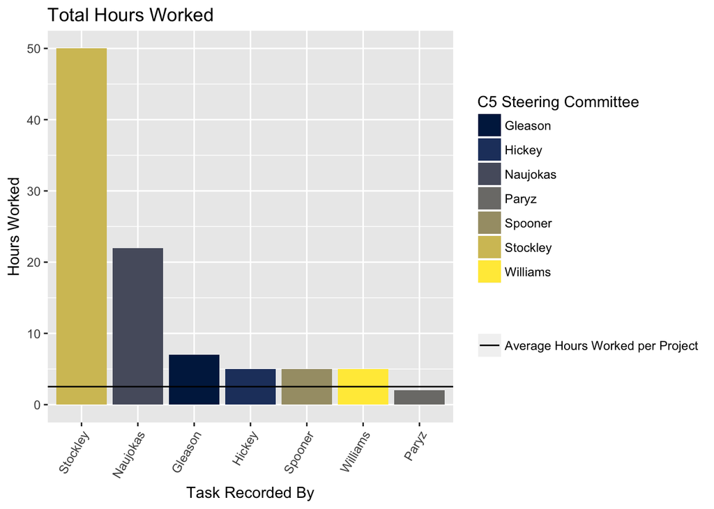

Automating the report programatically does not just cut down on errors by eliminating the cut/copy-paste-from-a-spreadsheet-to-a-word-document step. It also allows for customization. First and foremost, the graph’s labels can be edited, and the color scheme can be set to a color-blind friendly scheme. Additionally, this report can fix DCPO Spooner’s name so she is attributed accordingly.

All of the names in the document stem from the email addresses used in the form. The reason is simple: Most emails are `firstname.lastname@cookcountyil.gov`. This allows for a simple function to split the first and last name. DCPO Spooher, however, presents a challenge as her email is `melissa.parise@cookcountyil.gov`. Fixing this would be difficult in the spreadsheet, but given the nature of this report, it is a trivial task.

This would allow for quick, easy, and repeateable reporting with a few extra lines of code, all without having to cut and paste between Excel/Google Sheets and Word.